# ASC_TIMEcourse_limma_plusDay15_more_contrasts

Sarah Hp

6/4/22

Calculate time effect for timecourse of abdo and glut samples

- day15 floating and bulk samples to get DE stats on the combined timecourse effect (with floating and bulk separate??).

Adding extra contrasts for pro -> day0 -> day15 GO day0 -> day15 **NB: I added robust=TRUE to the eBayes calls on 27/3/20 (in the original timecourse analysis which did not include day15), but the files haven’t been regenerated. So robust=FALSE there.**

```r
ous_dir = "C:/Users/sarahhp/OneDrive - Universitetet i Oslo/OUS"
```

Load combined read counts from the previous analysis

```r
whole = read.delim(file.path(ous_dir, "Feb22_RNAseq/03limma/late_adipo_and_D7&D13_native_rnaseq.counts"), sep="\t", check.names = F )
whole_info = read.delim(file.path(ous_dir, "Feb22_RNAseq/03limma/late_adipo_and_D7&D13_native_rnaseq_info.tab"), sep="\t")
whole_info$donor = gsub("D13A","D13-A",whole_info$donor)
```

## Make DGE object

remove additional samples.

```r
whole_info$time.donor = paste(whole_info$time, whole_info$donor, sep=".")
whole_info$group = paste(whole_info$time.donor, whole_info$separation, sep=".")

whole_ob = DGEList(counts=data.matrix(whole[grep("[[:digit:]]", colnames(whole))]),
                   genes= whole[c("Geneid", "Length")], samples = whole_info)
rownames(whole_ob$counts) = whole_ob$genes$Geneid
summary (whole_ob)
```

```
##         Length  Class      Mode
## counts  3641570 -none-     numeric
## samples      11 data.frame list
## genes         2 data.frame list
```

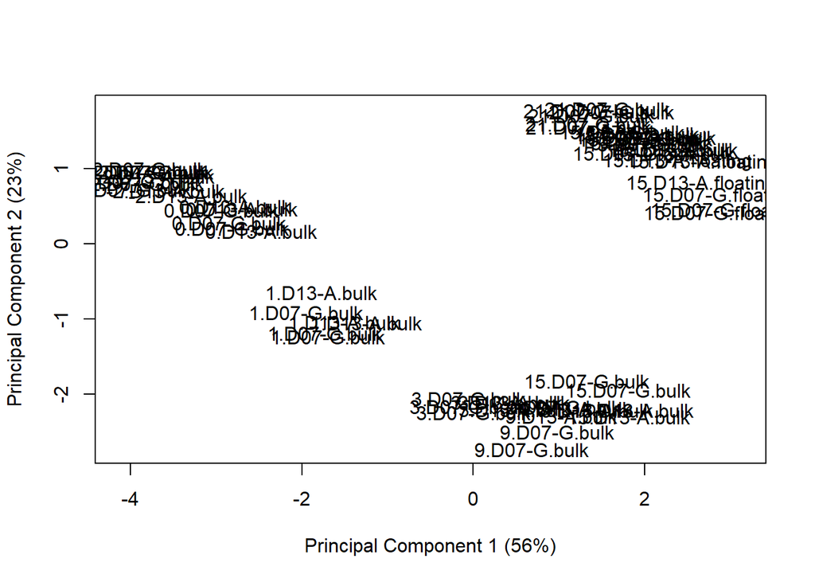

```r
plotMDS(whole_ob, labels = whole_ob$samples$group, gene.selection = "common")
```

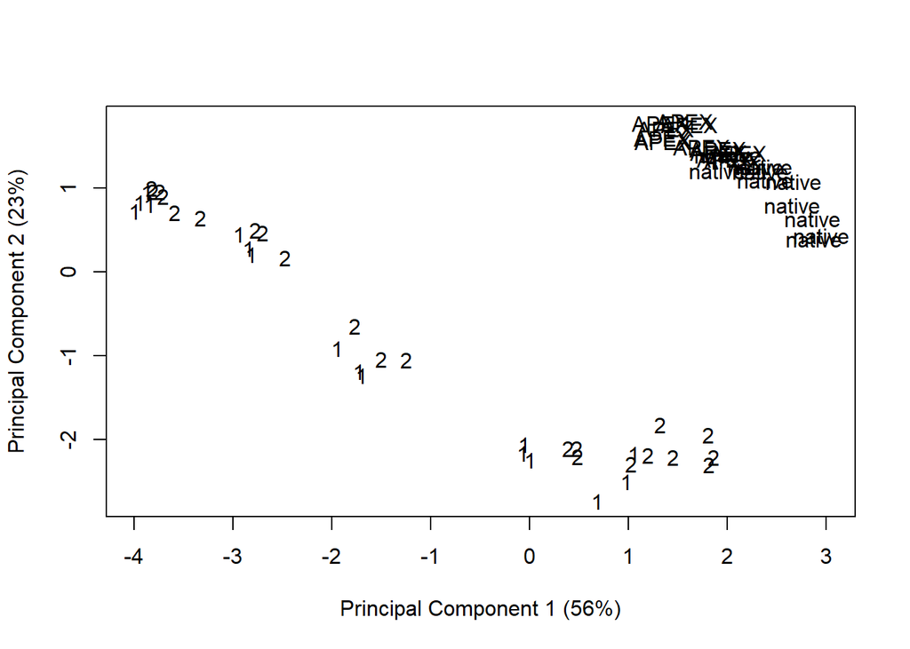

```r
plotMDS(whole_ob, labels = whole_ob$samples$exp, gene.selection = "common")
```

```r
#Remove uncultured mature adipocytes from tissue extract
series_ob = whole_ob[,!(whole_ob$samples$exp == 2 & whole_ob$samples$time == 15)]
table(paste(series_ob$samples$group, whole_ob$samples$exp))
```

```
##
##          -2.D07-G.bulk 1          -2.D07-G.bulk 2          -2.D13-A.bulk 2
##                        2                        5                        3
##     -2.D13-A.bulk native           0.D07-G.bulk 1           0.D13-A.bulk 2
##                        1                        3                        3
##      0.D13-A.bulk native           1.D07-G.bulk 1           1.D13-A.bulk 2
##                        1                        3                        3
##      1.D13-A.bulk native          15.D07-G.bulk 1       15.D07-G.bulk APEX
##                        1                        4                        2
##     15.D07-G.bulk native   15.D07-G.floating APEX     15.D13-A.bulk native
##                        3                        3                        3
##   15.D13-A.floating APEX 15.D13-A.floating native       21.D07-G.bulk APEX
##                        1                        2                        6
##           3.D07-G.bulk 1           3.D07-G.bulk 2           3.D13-A.bulk 2
##                        2                        1                        3
##      3.D13-A.bulk native           9.D07-G.bulk 1           9.D07-G.bulk 2
##                        1                        2                        1
##           9.D13-A.bulk 2
##                        3
```

```r
#remove APEX samples
series_ob = series_ob[,series_ob$samples$construct == "native"]

#Check column names are the same
series_ob$samples
```

```
##                              group lib.size norm.factors        sample_id time
## 6.19190_S20          -2.D13-A.bulk 43343287            1      6-19190_S20   -2
## 7.19191_S1            0.D13-A.bulk 53954863            1       7-19191_S1    0
## 8.19192_S3            1.D13-A.bulk 44816024            1       8-19192_S3    1
## 9.19193_S6            3.D13-A.bulk 27650074            1       9-19193_S6    3
## 10.19194_S9           9.D13-A.bulk 33681648            1      10-19194_S9    9
## 11.19195_S12         -2.D13-A.bulk 44069380            1     11-19195_S12   -2
## 12.19196_S15          0.D13-A.bulk 33748947            1     12-19196_S15    0
## 13.19197_S18          1.D13-A.bulk 35268416            1     13-19197_S18    1
## 14.19198_S21          3.D13-A.bulk 38990845            1     14-19198_S21    3
## 15.19199_S2           9.D13-A.bulk 31648240            1      15-19199_S2    9
## 1.19200_S5           -2.D13-A.bulk 24715231            1       1-19200_S5   -2
## 2.19201_S8            0.D13-A.bulk 25887790            1       2-19201_S8    0
## 3.19202_S11           1.D13-A.bulk 67946021            1      3-19202_S11    1
## 4.19203_S14           3.D13-A.bulk 51335376            1      4-19203_S14    3
## 5.19204_S17           9.D13-A.bulk 41570892            1      5-19204_S17    9
## 20.S2.KD5NT_S16      -2.D07-G.bulk 28227567            1  20-S2-KD5NT_S16   -2
## 21.S7.KD6NT_S19      -2.D07-G.bulk 30639099            1  21-S7-KD6NT_S19   -2
## 22.S12.KD3NT_S22     -2.D07-G.bulk 39314312            1 22-S12-KD3NT_S22   -2
## 1.KD4NT_S1           -2.D07-G.bulk 40875335            1       1.KD4NT_S1   -2
## 10.P6D3_S10           3.D07-G.bulk 37487858            1      10.P6D3_S10    3
## 11.P6D9_S11           9.D07-G.bulk 45348216            1      11.P6D9_S11    9
## 12.KD3NT_S12         -2.D07-G.bulk 52250725            1     12.KD3NT_S12   -2
## 13.P8D0_S13           0.D07-G.bulk 50473193            1      13.P8D0_S13    0
## 14.P8D1_S14           1.D07-G.bulk 37355443            1      14.P8D1_S14    1
## 15.P8D3_S15           3.D07-G.bulk 36821008            1      15.P8D3_S15    3
## 16.P8D9_S16           9.D07-G.bulk 25192201            1      16.P8D9_S16    9
## 2.KD5NT_S2           -2.D07-G.bulk 39256967            1       2.KD5NT_S2   -2
## 3.P5D0_S3             0.D07-G.bulk 35885732            1        3.P5D0_S3    0
## 4.P5D1_S4             1.D07-G.bulk 44499333            1        4.P5D1_S4    1
## 5.P5D3_S5             3.D07-G.bulk 45252924            1        5.P5D3_S5    3
## 6.P5D9_S6             9.D07-G.bulk 38835735            1        6.P5D9_S6    9
## 7.KD6NT_S7           -2.D07-G.bulk 37829067            1       7.KD6NT_S7   -2
## 8.P6D0_S8             0.D07-G.bulk 38988386            1        8.P6D0_S8    0
## 9.P6D1_S9             1.D07-G.bulk 40833777            1        9.P6D1_S9    1
## 13.21417_S53     15.D07-G.floating 39520835            1     13.21417_S53   15
## 14.21418_S2      15.D07-G.floating 43198916            1      14.21418_S2   15
## 15.21419_S9      15.D07-G.floating 53192791            1      15.21419_S9   15
## 16.21420_S16     15.D13-A.floating 58757001            1     16.21420_S16   15
## 17.21421_S24     15.D13-A.floating 64220795            1     17.21421_S24   15
```

[output cut: 39 more lines]

```
## 7.KD6NT_S7       D07-G     P6      1    native       bulk   -2.D07-G
## 8.P6D0_S8        D07-G     P6      1    native       bulk    0.D07-G
## 9.P6D1_S9        D07-G     P6      1    native       bulk    1.D07-G
## 13.21417_S53     D07-G     P6 native    native   floating   15.D07-G
## 14.21418_S2      D07-G   P8_1 native    native   floating   15.D07-G
## 15.21419_S9      D07-G   P8_2 native    native   floating   15.D07-G
## 16.21420_S16     D13-A   P6_1 native    native   floating   15.D13-A
## 17.21421_S24     D13-A   P6_2 native    native   floating   15.D13-A
## 18.21422_S32     D13-A     P7 native    native   floating   15.D13-A
## 19.21423_S40     D07-G     P7 native    native       bulk   15.D07-G
## 20.21424_S47     D07-G   P8_2 native    native       bulk   15.D07-G
## 21.21425_S54     D07-G   P8_1 native    native       bulk   15.D07-G
## 22.21426_S3      D13-A     P7 native    native       bulk   15.D13-A
## 23.21427_S10     D13-A     P6 native    native       bulk   15.D13-A
## 24.21428_S17     D13-A     P7 native    native       bulk   15.D13-A
```

```r
colnames(series_ob)
```

```
##  [1] "6.19190_S20"      "7.19191_S1"       "8.19192_S3"       "9.19193_S6"
##  [5] "10.19194_S9"      "11.19195_S12"     "12.19196_S15"     "13.19197_S18"
##  [9] "14.19198_S21"     "15.19199_S2"      "1.19200_S5"       "2.19201_S8"
## [13] "3.19202_S11"      "4.19203_S14"      "5.19204_S17"      "20.S2.KD5NT_S16"
## [17] "21.S7.KD6NT_S19"  "22.S12.KD3NT_S22" "1.KD4NT_S1"       "10.P6D3_S10"
## [21] "11.P6D9_S11"      "12.KD3NT_S12"     "13.P8D0_S13"      "14.P8D1_S14"
## [25] "15.P8D3_S15"      "16.P8D9_S16"      "2.KD5NT_S2"       "3.P5D0_S3"
## [29] "4.P5D1_S4"        "5.P5D3_S5"        "6.P5D9_S6"        "7.KD6NT_S7"
## [33] "8.P6D0_S8"        "9.P6D1_S9"        "13.21417_S53"     "14.21418_S2"
## [37] "15.21419_S9"      "16.21420_S16"     "17.21421_S24"     "18.21422_S32"
## [41] "19.21423_S40"     "20.21424_S47"     "21.21425_S54"     "22.21426_S3"
## [45] "23.21427_S10"     "24.21428_S17"
```

## Initial Plots

Everything looks good. 1. MDSplot separates timepoints well 2. the RLE plot shows that median counts between libraries are 0, meaning library size and distribution is similar between libraries. Therefore normalisation between experiments is not necessary.

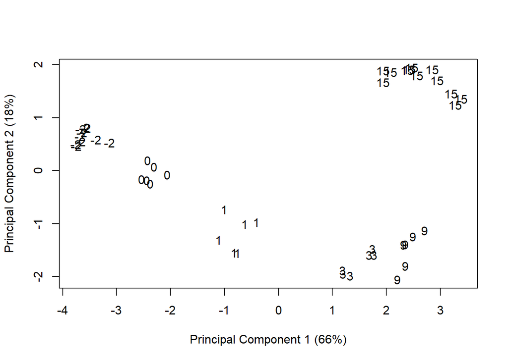

```r
plotMDS(series_ob, labels = series_ob$samples$time, gene.selection = "common")
```

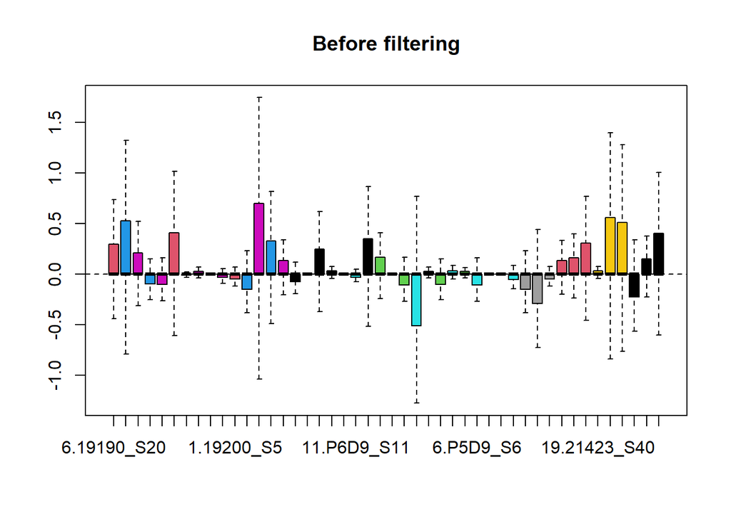

```r
plotRLE(series_ob$counts, outline=FALSE, col=series_ob$samples$group, main="Before filtering")
```

## Filtering

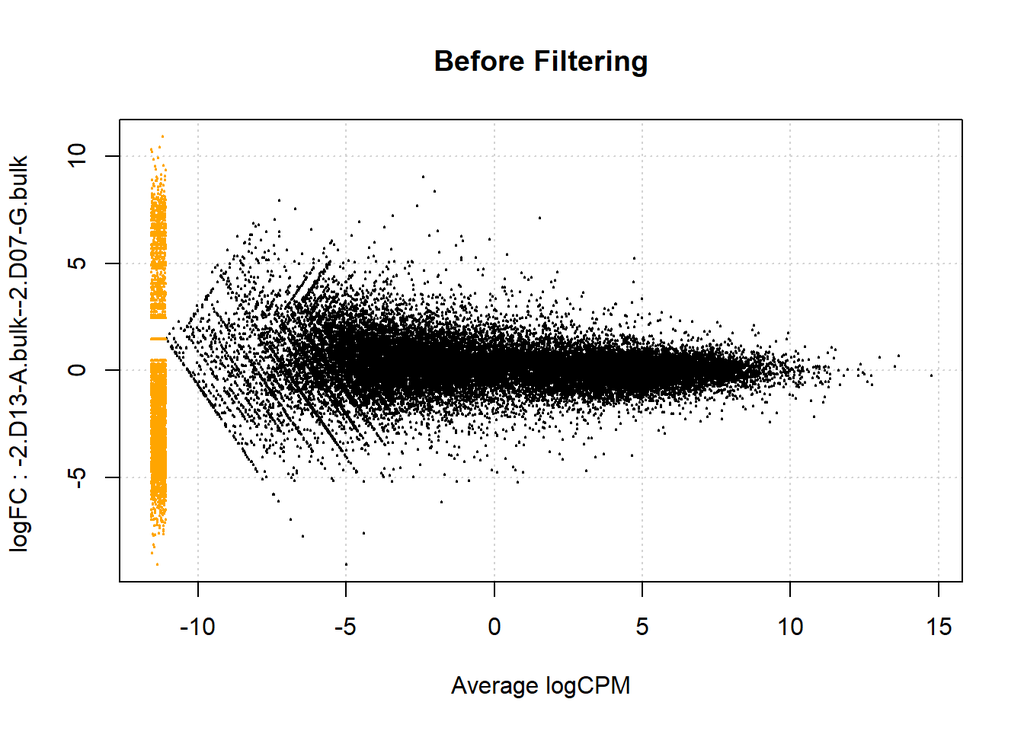

```r
plotSmear(series_ob, main = "Before Filtering")
```

```r
dim(series_ob)
```

```
## [1] 58735    46
```

```r
filt_series = series_ob[filterByExpr(series_ob),, keep.lib.sizes=FALSE]
dim(filt_series) #21174 genes kept (about 1k more genes that the timecourse to day9)
```

```
## [1] 21174    46
```

```r
#The filter is approxiamtely 10/ libsize in millions
10/(median(series_ob$samples$lib.size)/1000000) #0.245 minimum CPM
```

```
## [1] 0.2447707
```

```r
#sanity check that gene_names match up
filt_series$counts[filt_series$genes$Geneid == "ENSG00000228630",] #HOTAIR
```

```
##      6.19190_S20       7.19191_S1       8.19192_S3       9.19193_S6
##            67.00            60.00            61.00            26.00
##      10.19194_S9     11.19195_S12     12.19196_S15     13.19197_S18
##            18.00            39.00            52.00            36.00
##     14.19198_S21      15.19199_S2       1.19200_S5       2.19201_S8
##            41.00            15.00            18.00            46.00
##      3.19202_S11      4.19203_S14      5.19204_S17  20.S2.KD5NT_S16
##           105.00            37.00            12.00           200.00
##  21.S7.KD6NT_S19 22.S12.KD3NT_S22       1.KD4NT_S1      10.P6D3_S10
##           251.90           313.00           276.00           325.00
##      11.P6D9_S11     12.KD3NT_S12      13.P8D0_S13      14.P8D1_S14
##            96.00           427.00           770.25           462.00
##      15.P8D3_S15      16.P8D9_S16       2.KD5NT_S2        3.P5D0_S3
##           237.00           106.00           196.00           375.00
##        4.P5D1_S4        5.P5D3_S5        6.P5D9_S6       7.KD6NT_S7
##           454.00           438.00           151.00           342.00
##        8.P6D0_S8        9.P6D1_S9     13.21417_S53      14.21418_S2
##           595.00           330.00            71.00            41.00
##      15.21419_S9     16.21420_S16     17.21421_S24     18.21422_S32
##            71.00            26.00            11.00            15.00
##     19.21423_S40     20.21424_S47     21.21425_S54      22.21426_S3
##           339.00           797.12           844.00            26.00
##     23.21427_S10     24.21428_S17
##            78.00            47.00
```

```r
filt_series$counts[filt_series$genes$Geneid == "ENSG00000132170",] #PPARG
```

```
##      6.19190_S20       7.19191_S1       8.19192_S3       9.19193_S6
##          1303.10          1667.00          3994.00          6675.10
##      10.19194_S9     11.19195_S12     12.19196_S15     13.19197_S18
##          7365.24          1319.10           557.12          3194.31
##     14.19198_S21      15.19199_S2       1.19200_S5       2.19201_S8
##          7950.67          9278.10           542.00           671.00
##      3.19202_S11      4.19203_S14      5.19204_S17  20.S2.KD5NT_S16
##          4561.33          8161.83         11953.80           392.20
##  21.S7.KD6NT_S19 22.S12.KD3NT_S22       1.KD4NT_S1      10.P6D3_S10
##          1183.37          1248.50           743.00          3307.83
##      11.P6D9_S11     12.KD3NT_S12      13.P8D0_S13      14.P8D1_S14
##          5122.53           976.17           645.00          1255.00
##      15.P8D3_S15      16.P8D9_S16       2.KD5NT_S2        3.P5D0_S3
##          3011.50          3613.41           537.00           262.00
##        4.P5D1_S4        5.P5D3_S5        6.P5D9_S6       7.KD6NT_S7
##           886.00          3387.60          6195.75           793.00
##        8.P6D0_S8        9.P6D1_S9     13.21417_S53      14.21418_S2
##           537.10          1261.10         20687.05         21560.08
##      15.21419_S9     16.21420_S16     17.21421_S24     18.21422_S32
##         19293.64         30703.87         32751.01         38751.89
##     19.21423_S40     20.21424_S47     21.21425_S54      22.21426_S3
##         10886.47         12895.56         13914.89          8218.48
##     23.21427_S10     24.21428_S17
##         16600.64         18475.29
```

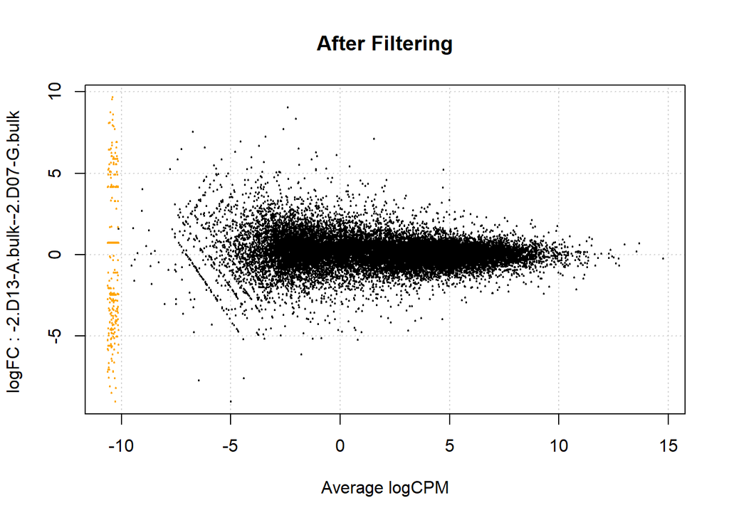

```r
plotSmear(filt_series, main = "After Filtering")
```

Donor vs donor this looks like very nice filtering (above, at any one time point some genes will be missing).

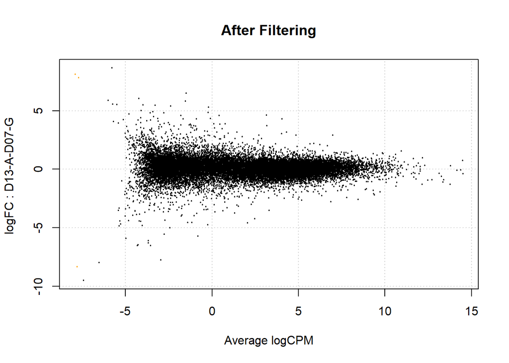

```r
#Plot donor v donor -> a few low exression genes still but predominantly good filtering
two_filt = filt_series
two_filt$samples$group = as.factor(filt_series$samples$donor)
plotSmear(two_filt, main = "After Filtering")
```

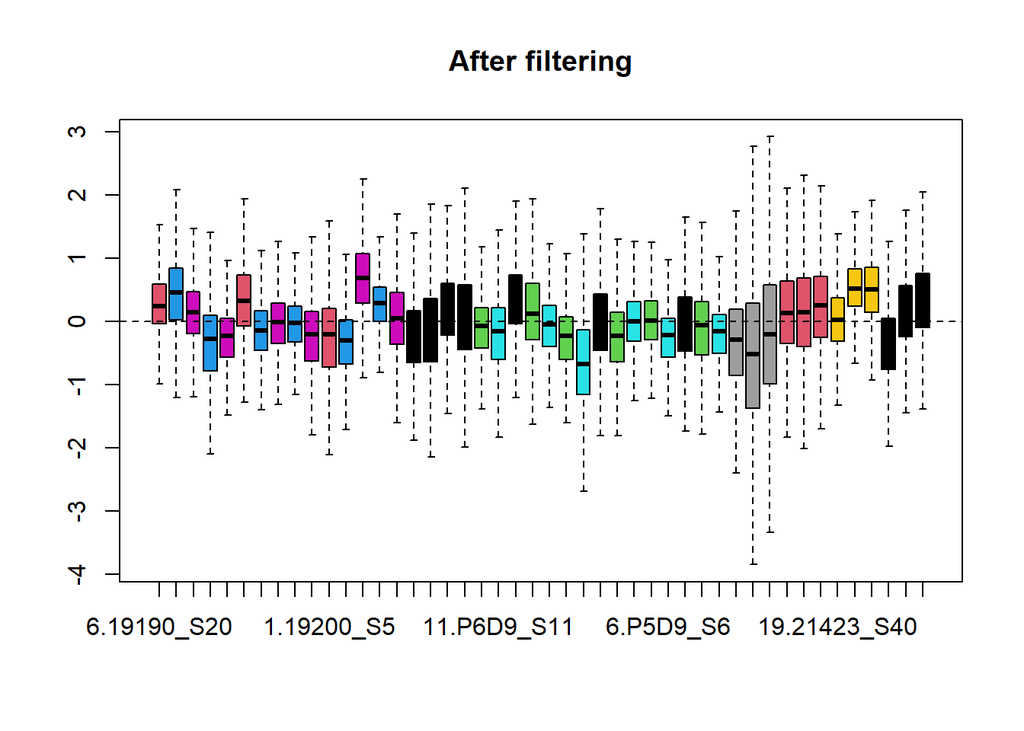

```r
#library sizes are different, but relative log expression is
#now ~ normally distributed within libraries
plotRLE(filt_series$counts, outline=FALSE,
        col=filt_series$samples$group, main="After filtering")
```

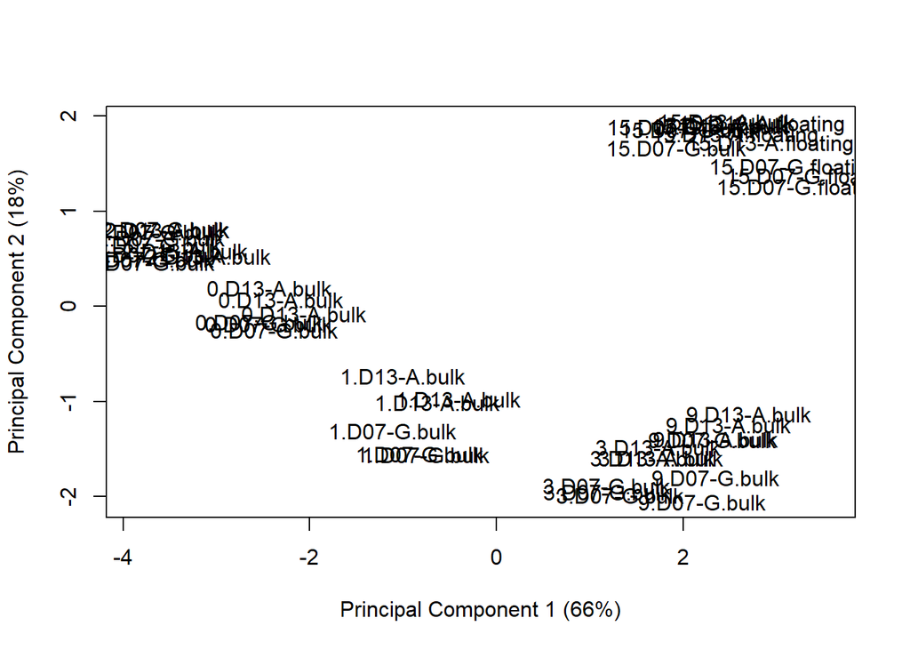

```r
plotMDS(filt_series, labels = filt_series$samples$group, gene.selection = "common")
```

## Normalise

```r
filt_series = calcNormFactors(filt_series,method = "TMM")
filt_series$samples$norm.factors
```

```
##  [1] 1.2453986 1.2143882 1.1251972 1.1279211 0.9458408 1.3221194 1.0006546
##  [8] 1.1403460 0.9928426 1.0445386 1.3664858 1.1431916 1.2621681 1.0546902
## [15] 1.0419210 1.2097179 1.3116400 1.2920327 1.1244080 0.9952023 0.7803853
## [22] 1.1123322 0.9314573 1.0344096 0.8685083 0.8944944 1.1077116 0.8561957
## [29] 0.9462983 0.9419903 0.8237695 1.1048732 0.9582887 0.8541723 0.7900871
## [36] 0.6108574 0.6834328 0.8374546 0.7701204 0.8412614 0.9839905 1.0048132
## [43] 1.0123257 0.9974582 0.9286878 1.0430292
```

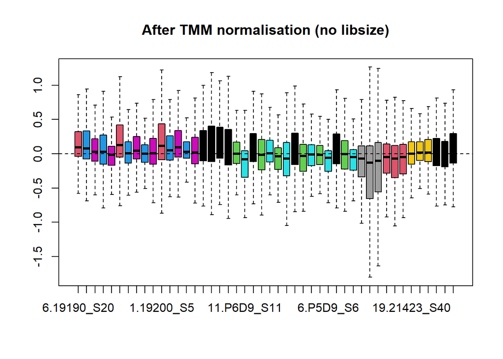

```r
plotRLE(cpm(filt_series$counts), outline=FALSE,
        col=filt_series$samples$group, main="After TMM normalisation (no libsize)")
```

Library size is approximately the same after CPM normalisation, but it still needs to be adjusted directly for library size:

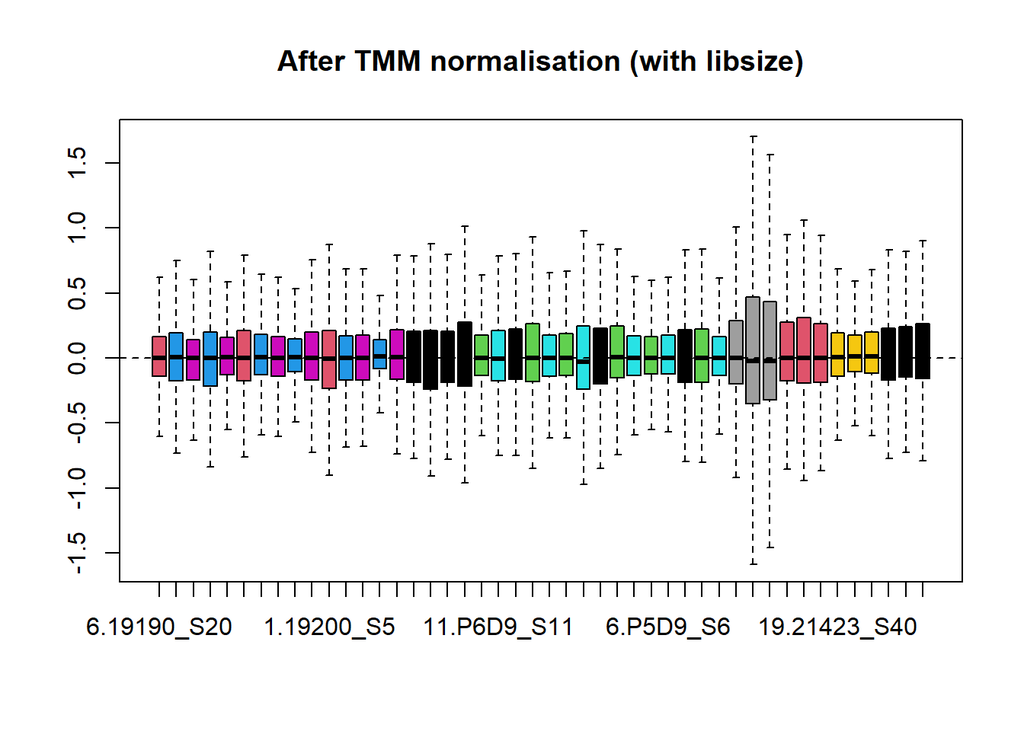

```r
plotRLE(cpm(filt_series, normalized.lib.sizes = TRUE), outline=FALSE,
        col=filt_series$samples$group, main="After TMM normalisation (with libsize)")
```

## Annotate Gene Lists

```r
library(biomaRt)
mart <- biomaRt::useMart(biomart = "ensembl",
  dataset = "hsapiens_gene_ensembl",
   host = "https://jan2019.archive.ensembl.org")
annot = getBM(c("external_gene_name", "description", "ensembl_gene_id"),
              filters = "ensembl_gene_id",
              values = filt_series$genes$Geneid,
              mart = mart)

head(annot, n=2); dim(annot)
```

```
##   external_gene_name                                       description
## 1             TSPAN6 tetraspanin 6 [Source:HGNC Symbol;Acc:HGNC:11858]
## 2               TNMD   tenomodulin [Source:HGNC Symbol;Acc:HGNC:17757]
##   ensembl_gene_id
## 1 ENSG00000000003
## 2 ENSG00000000005
```

```
## [1] 21174     3
```

```r
#Tidying up the annot table
annot$description = gsub("\\[Source:.+\\]", "", annot$description)
colnames(annot)[1] = "gene_name"

#Add gene names to filt_series
filt_series$genes = merge(filt_series$genes, annot, by.x= "Geneid",
                        by.y = "ensembl_gene_id", sort=FALSE)
#head(filt_series$genes)
#make sure length is numeric
filt_series$genes$Length = as.numeric(filt_series$genes$Length)
```

## Limma Log Normalisation

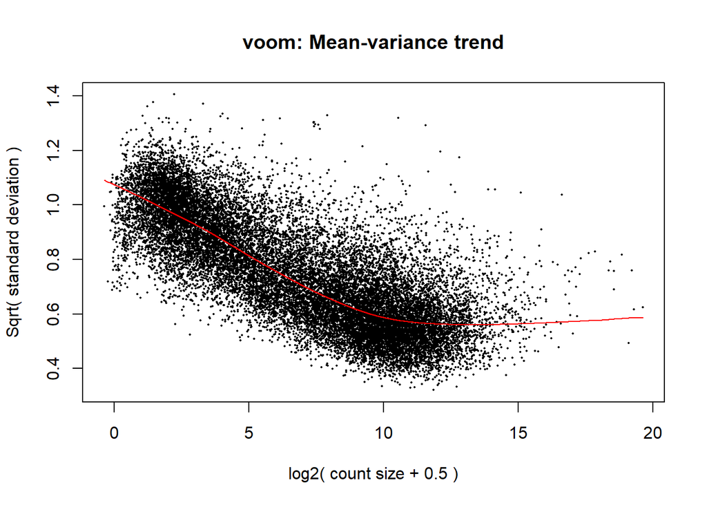

```r
norm_series = voom(filt_series, plot = TRUE)
```

```r
head(norm_series$design, n=2) #groups are time.donor
```

```
##             (Intercept) group-2.D13-A.bulk group0.D07-G.bulk group0.D13-A.bulk
## 6.19190_S20           1                  1                 0                 0
## 7.19191_S1            1                  0                 0                 1
##             group1.D07-G.bulk group1.D13-A.bulk group15.D07-G.bulk
## 6.19190_S20                 0                 0                  0
## 7.19191_S1                  0                 0                  0
##             group15.D07-G.floating group15.D13-A.bulk group15.D13-A.floating
## 6.19190_S20                      0                  0                      0
## 7.19191_S1                       0                  0                      0
##             group3.D07-G.bulk group3.D13-A.bulk group9.D07-G.bulk
## 6.19190_S20                 0                 0                 0
## 7.19191_S1                  0                 0                 0
##             group9.D13-A.bulk
## 6.19190_S20                 0
## 7.19191_S1                  0
```

```r
summary(norm_series$E[,1])#log normlisation min -6, max 14
```

```
##    Min. 1st Qu.  Median    Mean 3rd Qu.    Max.
##  -6.754  -1.468   1.972   1.594   4.635  14.871
```

## Design

How to separate floating and bulk adipocytes? Perhaps I’ll need to run the analysis separately, but start together with the separation as a factor.

```r
#1 check the default design
colnames(norm_series$design)
```

```
##  [1] "(Intercept)"            "group-2.D13-A.bulk"     "group0.D07-G.bulk"
##  [4] "group0.D13-A.bulk"      "group1.D07-G.bulk"      "group1.D13-A.bulk"
##  [7] "group15.D07-G.bulk"     "group15.D07-G.floating" "group15.D13-A.bulk"
## [10] "group15.D13-A.floating" "group3.D07-G.bulk"      "group3.D13-A.bulk"
## [13] "group9.D07-G.bulk"      "group9.D13-A.bulk"
```

```r
head(filt_series$samples, n=2)
```

```
##                     group lib.size norm.factors   sample_id time donor biorep
## 6.19190_S20 -2.D13-A.bulk 43327502     1.245399 6-19190_S20   -2 D13-A      7
## 7.19191_S1   0.D13-A.bulk 53932903     1.214388  7-19191_S1    0 D13-A      7
##             exp construct separation time.donor
## 6.19190_S20   2    native       bulk   -2.D13-A
## 7.19191_S1    2    native       bulk    0.D13-A
```

```r
pair_design = model.matrix(~0+filt_series$samples$group)
colnames(pair_design) = paste("day", gsub("-",".",levels(filt_series$samples$group)), sep="")
rownames(pair_design) = filt_series$samples$sample_id
head(pair_design, n=2)
```

```
##             day.2.D07.G.bulk day.2.D13.A.bulk day0.D07.G.bulk day0.D13.A.bulk
## 6-19190_S20                0                1               0               0
## 7-19191_S1                 0                0               0               1
##             day1.D07.G.bulk day1.D13.A.bulk day15.D07.G.bulk
## 6-19190_S20               0               0                0
## 7-19191_S1                0               0                0
##             day15.D07.G.floating day15.D13.A.bulk day15.D13.A.floating
## 6-19190_S20                    0                0                    0
## 7-19191_S1                     0                0                    0
##             day3.D07.G.bulk day3.D13.A.bulk day9.D07.G.bulk day9.D13.A.bulk
## 6-19190_S20               0               0               0               0
## 7-19191_S1                0               0               0               0
```

## Making a large time based model

Using bulk day15 samples time_effect_donor7 + time_effect_donor13 was the pvalue used at 0.01 to select genes for dpgp

```r
pair_fit = lmFit(norm_series, design=pair_design)

contrasts = makeContrasts(time_effect_donor7 = (day0.D07.G.bulk - day.2.D07.G.bulk ) + #D-2 -> D0 effect
                                                  (day1.D07.G.bulk - day0.D07.G.bulk) + #D0 -> D1 effect
                                                  (day3.D07.G.bulk - day1.D07.G.bulk) + #D1 -> D3 effect
                                                  (day9.D07.G.bulk - day3.D07.G.bulk) + #D3 -> D9 effect
                                                  (day15.D07.G.bulk - day9.D07.G.bulk),
                          time_effect_donor13 = (day0.D13.A.bulk - day.2.D13.A.bulk ) + #D-2 -> D0 effect
                                                  (day1.D13.A.bulk - day0.D13.A.bulk) + #D0 -> D1 effect
                                                  (day3.D13.A.bulk - day1.D13.A.bulk) + #D1 -> D3 effect
                                                  (day9.D13.A.bulk - day3.D13.A.bulk) + #D3 -> D9 effect
                                                  (day15.D13.A.bulk - day9.D13.A.bulk), #D9 -> D15 effect
                          time_effect_per_donor = ((day0.D07.G.bulk - day.2.D07.G.bulk ) + #donor 7
                                                  (day1.D07.G.bulk - day0.D07.G.bulk) +
                                                  (day3.D07.G.bulk - day1.D07.G.bulk) +
                                                  (day9.D07.G.bulk - day3.D07.G.bulk) +
                                                  (day15.D07.G.bulk - day9.D07.G.bulk)) - #minus
                                                  ((day0.D13.A.bulk - day.2.D13.A.bulk ) + #donor 13
                                                  (day1.D13.A.bulk - day0.D13.A.bulk) +
                                                  (day3.D13.A.bulk - day1.D13.A.bulk) +
                                                  (day9.D13.A.bulk - day3.D13.A.bulk) +
                                                  (day15.D13.A.bulk - day9.D13.A.bulk)),
                          levels=pair_design)
special_fit = contrasts.fit(pair_fit,contrasts)
special_fit = eBayes(special_fit, robust = TRUE)
```

```r
summary(decideTests(special_fit, method="separate", adjust.method = "BH", p.value = 0.01)) #Adjusted for contrast
```

```
##        time_effect_donor7 time_effect_donor13 time_effect_per_donor
## Down                 4563                4558                    67
## NotSig              11929               12246                 20976
## Up                   4682                4370                   131
```

```r
summary(decideTests(special_fit ,method="global", adjust.method = "BH")) #Unadjusted for contrast
```

```
##        time_effect_donor7 time_effect_donor13 time_effect_per_donor
## Down                 5336                5534                  1399
## NotSig              10166               10173                 18229
## Up                   5672                5467                  1546
```

Interesting, the time effect is less significant in donor13. The time effect is similar rather than different between donors -> most genes respons similarly to adipogenic cocktail, regardless of depot/donor.

## Number of DE genes

Adding an extra timepoint adds more genes to the DE list; 11,639 genes at p < 0.01 (basically 50% of all detected genes).

```r
comb = topTable(special_fit, number = nrow(pair_fit$genes), coef = c("time_effect_donor7","time_effect_donor13"))
dim(comb[comb$adj.P.Val < 0.05,]) #More than half of all genes change; most will be the same
```

```
## [1] 14236    10
```

```r
dim(comb[comb$adj.P.Val < 0.01,])
```

```
## [1] 11639    10
```

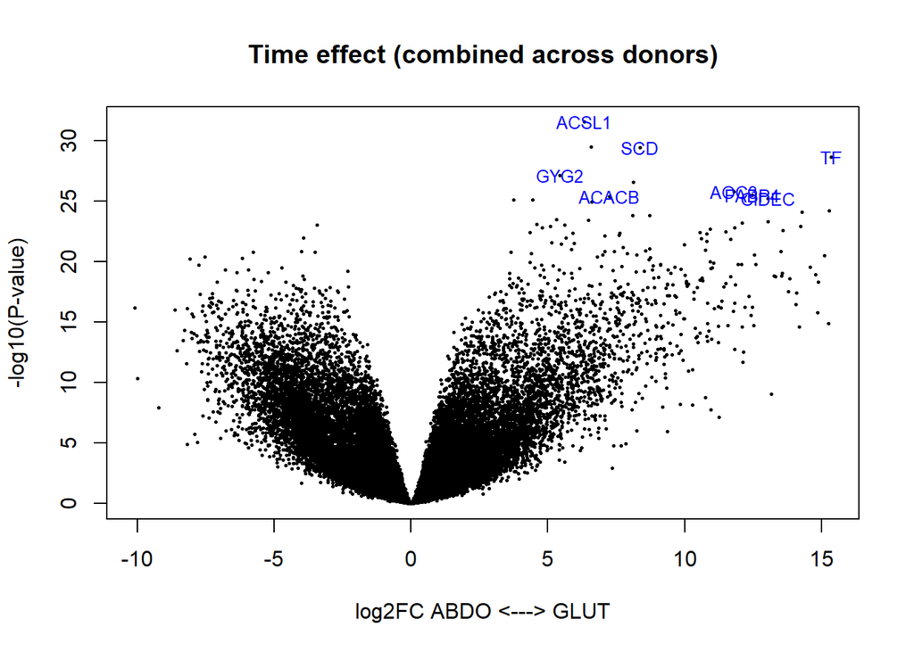

```r
volcanoplot(special_fit, coef = c(1,2), highlight =10, names = special_fit$genes$gene_name,
            main="Time effect (combined across donors)", xlab="log2FC ABDO <---> GLUT")
```

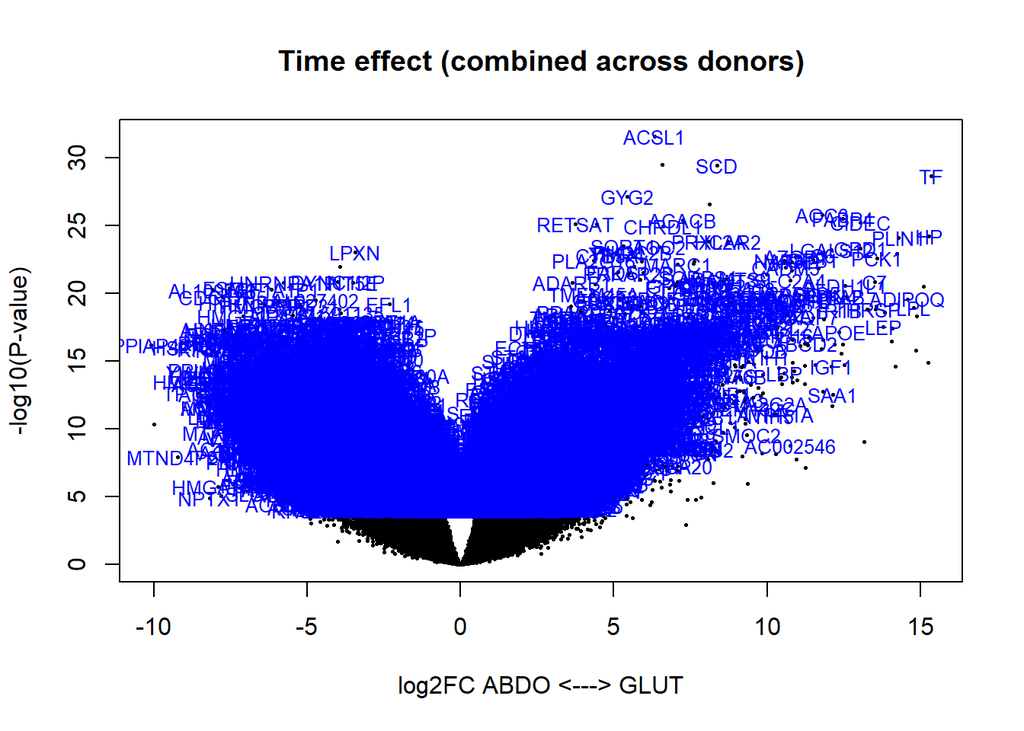

```r
volcanoplot(special_fit, coef = c(1,2), highlight =11639, names = special_fit$genes$gene_name,
            main="Time effect (combined across donors)", xlab="log2FC ABDO <---> GLUT")
```

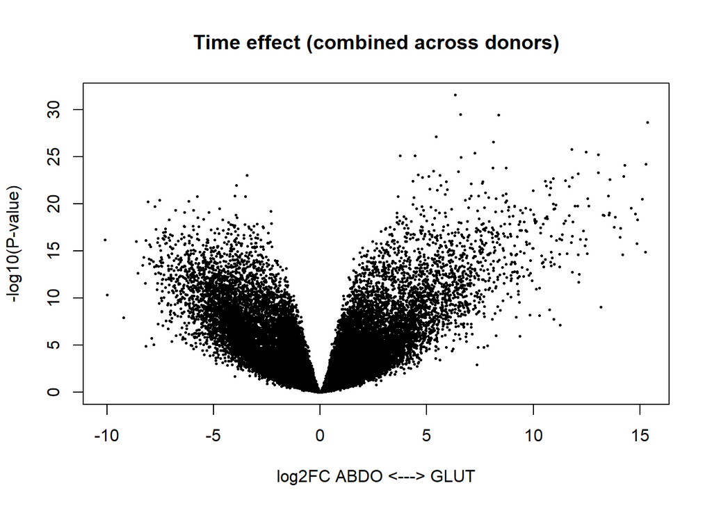

```r
volcanoplot(special_fit, coef = c(1,2),
            main="Time effect (combined across donors)", xlab="log2FC ABDO <---> GLUT")
```

```r
head(comb)
```

```
##                          Geneid Length gene_name
## ENSG00000151726 ENSG00000151726   6284     ACSL1
## ENSG00000099194 ENSG00000099194   5362       SCD
## ENSG00000091513 ENSG00000091513  26199        TF
## ENSG00000056998 ENSG00000056998   3655      GYG2
## ENSG00000042445 ENSG00000042445   4005    RETSAT
## ENSG00000131471 ENSG00000131471   4524      AOC3
##                                                     description
## ENSG00000151726 acyl-CoA synthetase long chain family member 1
## ENSG00000099194                        stearoyl-CoA desaturase
## ENSG00000091513                                    transferrin
## ENSG00000056998                                   glycogenin 2
## ENSG00000042445                               retinol saturase
## ENSG00000131471             amine oxidase, copper containing 3
##                 time_effect_donor7 time_effect_donor13   AveExpr         F
## ENSG00000151726           6.328527            6.587910  8.810891 1311.9218
## ENSG00000099194           8.374125            8.116002 11.807874  977.5321
## ENSG00000091513          15.353000           14.232266  3.105257  772.2557
## ENSG00000056998           5.435924            4.592658  4.980263  682.1157
## ENSG00000042445           3.744336            4.451633  7.100134  664.3419
## ENSG00000131471          11.794312           11.680727  6.379407  583.7419
##                      P.Value    adj.P.Val
## ENSG00000151726 4.270495e-36 9.042346e-32
## ENSG00000099194 1.365663e-33 1.445828e-29
## ENSG00000091513 1.129907e-31 7.974881e-28
## ENSG00000056998 9.517809e-31 5.038252e-27
## ENSG00000042445 1.558726e-30 6.600891e-27
## ENSG00000131471 2.067426e-29 6.789009e-26
```

```r
#write.table(comb, sep="\t", row.names=FALSE,file.path(ous_dir, "Feb22_RNAseq/03limma/time_effect_perdonor.tab"))
```

Still, at p < 0.05 about 8k genes hit sig. in both donors separately, and 3k each only hit sig. in one donor. For the HOTAIR project we didn’t want to select consensus DE genes, because its only DE in Glut. For the nucleolus project it might have made sense to, but to match what’s gone before I don’t want to make it too complicated.

```r
donor7 = topTable(special_fit, number = nrow(pair_fit$genes), coef = c("time_effect_donor7"), adjust.method = "BH")
donor13 = topTable(special_fit, number = nrow(pair_fit$genes), coef = c("time_effect_donor13"))

donor7 = donor7[donor7$adj.P.Val < 0.05,]
donor13 = donor13[donor13$adj.P.Val < 0.05,]

dim(donor7);dim(donor13)
```

```
## [1] 11472    10
```

```
## [1] 11512    10
```

```r
both_donors = merge(donor7, donor13, all=FALSE, by="Geneid"); dim(both_donors)
```

```
## [1] 8152   19
```

```r
just13 = donor13[!(donor13$Geneid %in% donor7$Geneid),]
dim(just13)
```

```
## [1] 3360   10
```

```r
just7 = donor7[!(donor7$Geneid %in% donor13$Geneid),]
dim(just7)
```

```
## [1] 3320   10
```

Other plots to look at the difference

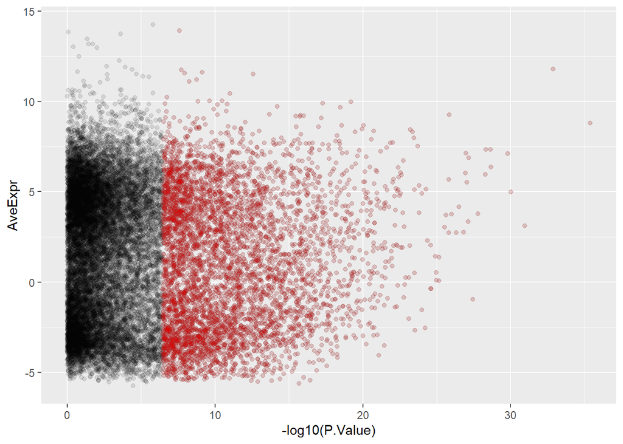

```r
library(ggplot2)
ggplot(comb, aes(y=AveExpr, x=-log10(P.Value))) + geom_point(alpha=0.1) +
  geom_point(data=comb[1:5000,], colour="red", alpha=0.1)
```

## log FC tables

```r
pair_cont = makeContrasts(#Donor 7 changes over time
                          d.2_to_d0.D7 = day0.D07.G.bulk - day.2.D07.G.bulk,
                          d0_to_d1.D7 = day1.D07.G.bulk - day0.D07.G.bulk,
                          d1_to_d3.D7 = day3.D07.G.bulk - day1.D07.G.bulk,
                          d3_to_d9.D7= day9.D07.G.bulk - day3.D07.G.bulk,
                          d9_to_d15.D7.bulk =  day15.D07.G.bulk - day9.D07.G.bulk,
                          d9_to_d15.D7.floating =  day15.D07.G.floating - day9.D07.G.bulk,
                          d15.bulk_to_floating.D7 = day15.D07.G.floating - day15.D07.G.bulk,
                          d0_to_d15.D7 = day15.D07.G.bulk - day0.D07.G.bulk,
                          #Donor 13 changes over time
                          d.2_to_d0.D13 = day0.D13.A.bulk - day.2.D13.A.bulk,
                          d0_to_d1.D13 = day1.D13.A.bulk - day0.D13.A.bulk,
                          d1_to_d3.D13 = day3.D13.A.bulk - day1.D13.A.bulk,
                          d3_to_d9.D13 = day9.D13.A.bulk - day3.D13.A.bulk,
                          d9_to_d15.D13.bulk =  day15.D13.A.bulk - day9.D13.A.bulk,
                          d9_to_d15.D13.floating =  day15.D13.A.floating - day9.D13.A.bulk,
                          d15.bulk_to_floating.D13 = day15.D13.A.floating - day15.D13.A.bulk,
                          d0_to_d15.D13 = day15.D13.A.bulk - day0.D13.A.bulk,
                          levels=pair_design)

pair_fit = contrasts.fit(pair_fit,pair_cont)
pair_fit = eBayes(pair_fit, robust = TRUE)
pair_tab = topTable(pair_fit, number = nrow(pair_fit$genes))

nrow(pair_tab[pair_tab$adj.P.Val < 0.01,])
```

```
## [1] 18335
```

Donor 13 has very similar bulk and floating; D7 bulk and floating are very different :P

```r
result = decideTests(pair_fit, p.value = 0.01)

summary(result)
```

```
##        d.2_to_d0.D7 d0_to_d1.D7 d1_to_d3.D7 d3_to_d9.D7 d9_to_d15.D7.bulk
## Down           2488        1437         250         319              3353
## NotSig        15508       18900       20481       20466             14120
## Up             3178         837         443         389              3701
##        d9_to_d15.D7.floating d15.bulk_to_floating.D7 d0_to_d15.D7 d.2_to_d0.D13
## Down                    4357                    3097         4134           909
## NotSig                 12264                   14860        13359         19492
## Up                      4553                    3217         3681           773
##        d0_to_d1.D13 d1_to_d3.D13 d3_to_d9.D13 d9_to_d15.D13.bulk
## Down           1301          619          178               3067
## NotSig        19021        19845        20687              15334
## Up              852          710          309               2773
##        d9_to_d15.D13.floating d15.bulk_to_floating.D13 d0_to_d15.D13
## Down                     3181                      131          3938
## NotSig                  14969                    20871         13504
## Up                       3024                      172          3732
```

```r
info = data.frame(t(summary(result)))
colnames(info) = c("test", "result", "freq")
info$donor = gsub("d.*_to_(d.*|floating)\\.", "", gsub(".(bulk|floating)$", "", info$test))
info$timezone = factor(gsub("\\.D(7|13)", "", info$test),
                       levels = c("d.2_to_d0","d0_to_d1", "d1_to_d3" ,"d3_to_d9" ,"d9_to_d15.bulk", "d9_to_d15.floating","d15.bulk_to_floating","d0_to_d15"))
info$result = factor(info$result, levels=c("Up","Down", "NotSig"))
info
```

```
##                        test result  freq donor             timezone
## 1              d.2_to_d0.D7   Down  2488    D7            d.2_to_d0
## 2               d0_to_d1.D7   Down  1437    D7             d0_to_d1
## 3               d1_to_d3.D7   Down   250    D7             d1_to_d3
## 4               d3_to_d9.D7   Down   319    D7             d3_to_d9
## 5         d9_to_d15.D7.bulk   Down  3353    D7       d9_to_d15.bulk
## 6     d9_to_d15.D7.floating   Down  4357    D7   d9_to_d15.floating
## 7   d15.bulk_to_floating.D7   Down  3097    D7 d15.bulk_to_floating
## 8              d0_to_d15.D7   Down  4134    D7            d0_to_d15
## 9             d.2_to_d0.D13   Down   909   D13            d.2_to_d0
## 10             d0_to_d1.D13   Down  1301   D13             d0_to_d1
## 11             d1_to_d3.D13   Down   619   D13             d1_to_d3
## 12             d3_to_d9.D13   Down   178   D13             d3_to_d9
## 13       d9_to_d15.D13.bulk   Down  3067   D13       d9_to_d15.bulk
## 14   d9_to_d15.D13.floating   Down  3181   D13   d9_to_d15.floating
```

[output cut: 34 more lines]

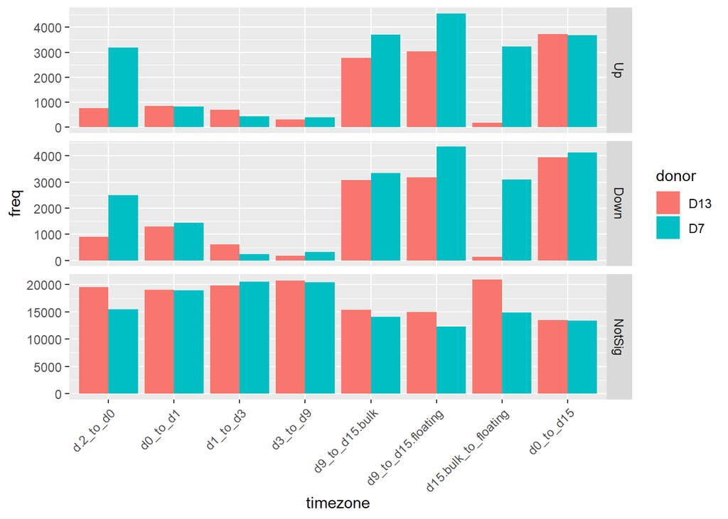

```r
ggplot(info) + geom_bar(stat="identity",aes(x=timezone,y=freq, fill=donor, group=donor), position="dodge") +
  theme(axis.text.x = element_text(angle=45, hjust=1)) + facet_grid(result~., scales = "free_y")
```

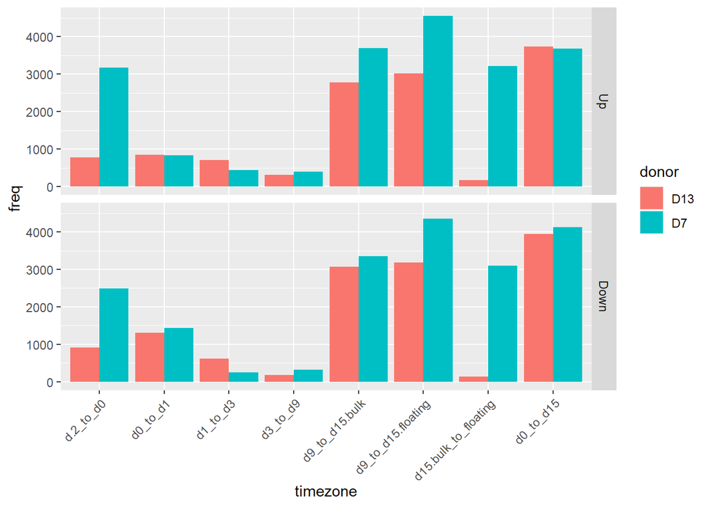

```r
ggplot(info[info$result != "NotSig",]) + geom_bar(stat="identity",aes(x=timezone,y=freq, fill=donor, group=donor), position="dodge") +
  theme(axis.text.x = element_text(angle=45, hjust=1)) + facet_grid(result~.)
```

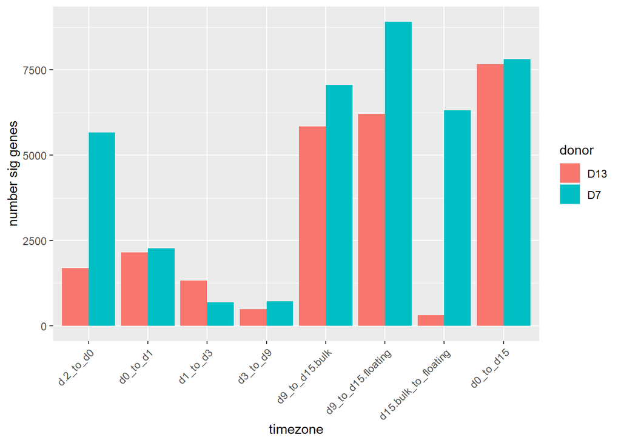

```r
ggplot(info[info$result != "NotSig",]) + geom_bar(stat="summary", fun="sum",aes(x=timezone,y=freq, fill=donor, group=donor), position="dodge") +
  theme(axis.text.x = element_text(angle=45, hjust=1)) + ylab("number sig genes")
```

Donor7 has more dynamic gene expression than donor13, particularly in cells becoming confluent and between bulk and floating adipocyte fractions. This means that when I do combined tests and analysis the effect is often driven by donor7 rather than donor13. It’s also notable that there is a huge difference in gene expression from day9 to day15, which will dominate over the more moderate effects seen in the early adipogenesis (from day0 to day9). It may make sense to streamline our timepoints or comparisons, to test more specific things. For example Pro -> D0 -> D9 -> D15

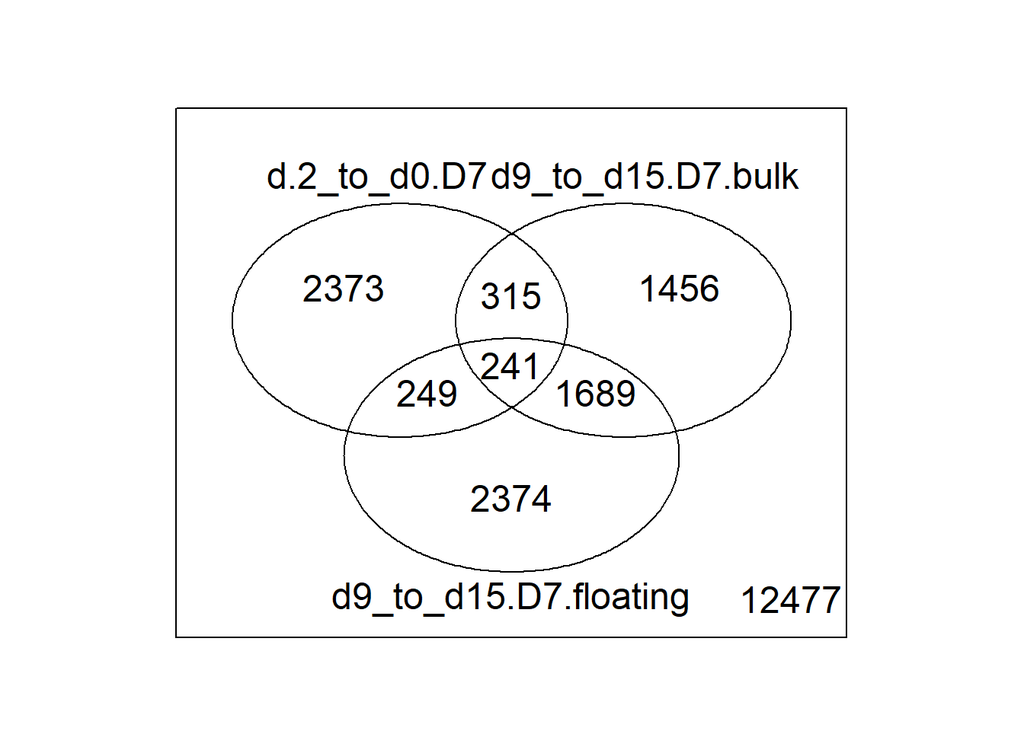

```r
vennDiagram(result[,c("d.2_to_d0.D7", "d9_to_d15.D7.bulk", "d9_to_d15.D7.floating")], include="up")
```

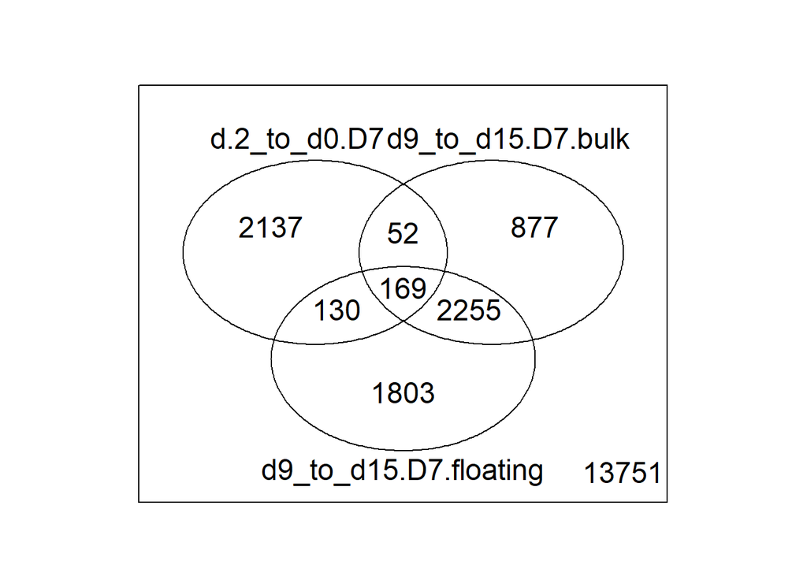

```r
vennDiagram(result[,c("d.2_to_d0.D7", "d9_to_d15.D7.bulk", "d9_to_d15.D7.floating")], include="down")
```

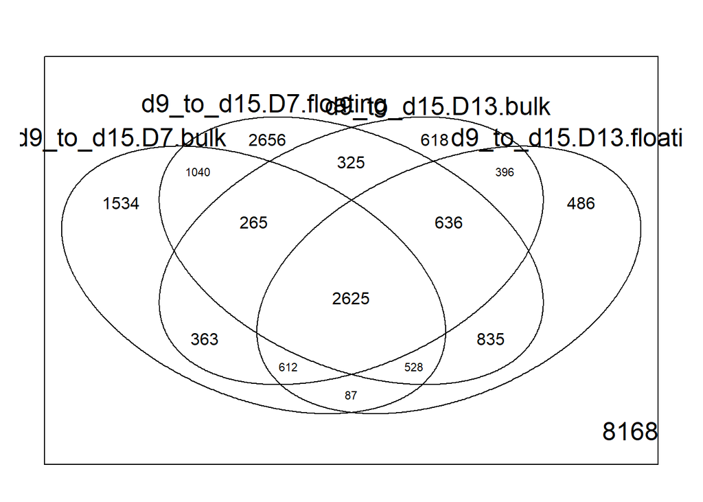

```r
vennDiagram(result[,c("d9_to_d15.D7.bulk", "d9_to_d15.D7.floating", "d9_to_d15.D13.bulk","d9_to_d15.D13.floating")])
```

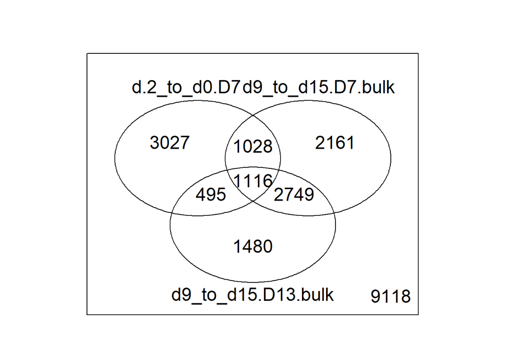

```r
vennDiagram(result[,c( "d.2_to_d0.D7","d9_to_d15.D7.bulk", "d9_to_d15.D13.bulk")]) #day-2 to day0 changing genes often also change d9 to d15
```

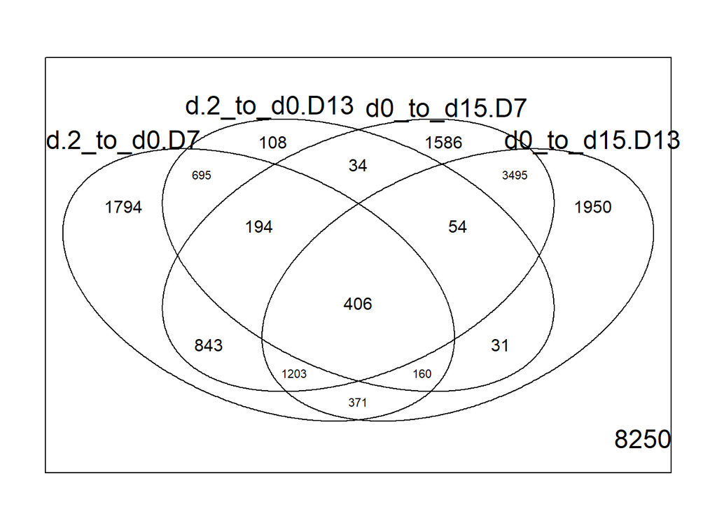

```r
vennDiagram(result[,c("d.2_to_d0.D7", "d.2_to_d0.D13","d0_to_d15.D7", "d0_to_d15.D13")])
```

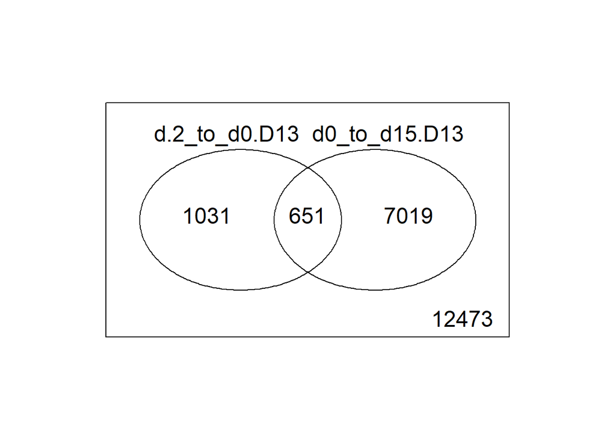

```r
vennDiagram(result[,c("d.2_to_d0.D13", "d0_to_d15.D13")])
```

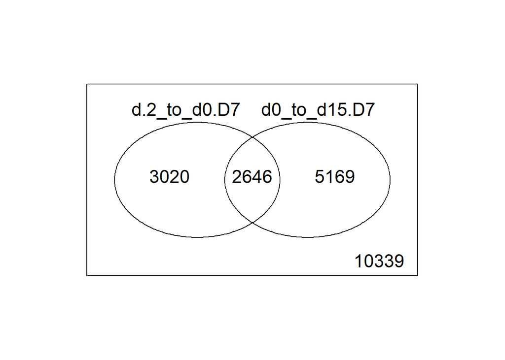

```r
vennDiagram(result[,c("d.2_to_d0.D7", "d0_to_d15.D7")])
```

```r
write.table(pair_tab,  sep="\t", row.names=FALSE,
            file.path(ous_dir, "Feb22_RNAseq/03limma/logFCs_timePairs_plus0v15.tab"))
```

Get an overview of these changes in a table form….

```r
dynamic = as.data.frame(result)
dynamic$sig_n = rowSums(result != 0)
dynamic$up_n = rowSums(result == 1)
dynamic$down_n = rowSums(result == -1)

head(dynamic)
```

```
##                 d.2_to_d0.D7 d0_to_d1.D7 d1_to_d3.D7 d3_to_d9.D7
## ENSG00000000003            0           0           0           0
## ENSG00000000005            0           0           0           0
## ENSG00000000419            0           0           0           0
## ENSG00000000457            0           0           0           0
## ENSG00000000460           -1           0           0           0
## ENSG00000000938            1           0           0           0
##                 d9_to_d15.D7.bulk d9_to_d15.D7.floating d15.bulk_to_floating.D7
## ENSG00000000003                 1                     1                       0
## ENSG00000000005                 0                     0                       0
## ENSG00000000419                 0                     0                       0
## ENSG00000000457                 0                     0                       0
## ENSG00000000460                 0                     0                       0
## ENSG00000000938                 0                     1                       1
##                 d0_to_d15.D7 d.2_to_d0.D13 d0_to_d1.D13 d1_to_d3.D13
## ENSG00000000003            1             0            0            0
## ENSG00000000005            1             0            0            0
## ENSG00000000419            0             0            0            0
## ENSG00000000457            0             0            0            0
## ENSG00000000460            0            -1            0            0
## ENSG00000000938            1             0            0            0
##                 d3_to_d9.D13 d9_to_d15.D13.bulk d9_to_d15.D13.floating
## ENSG00000000003            0                  0                      0
## ENSG00000000005            1                  0                      0
## ENSG00000000419            0                  0                      0
## ENSG00000000457            0                  0                      0
## ENSG00000000460            0                  0                      0
## ENSG00000000938            0                  1                      1
##                 d15.bulk_to_floating.D13 d0_to_d15.D13 sig_n up_n down_n
## ENSG00000000003                        0             0     3    3      0
## ENSG00000000005                        0             1     3    3      0
## ENSG00000000419                        0             0     0    0      0
## ENSG00000000457                        0             0     0    0      0
## ENSG00000000460                        0             0     2    0      2
## ENSG00000000938                        0             1     7    7      0
```

```r
table(dynamic$sig_n)
```

```
##
##    0    1    2    3    4    5    6    7    8    9   10   11   12   13   14   15
## 3722 3294 3235 2722 2110 1806 2272  997  497  258  146   67   32   12    3    1
```

```r
table(dynamic$up_n)
```

```
##
##    0    1    2    3    4    5    6    7    8    9   10   11   12   13   14
## 9455 4130 2399 1763 1270  930  628  346  141   69   25   11    5    1    1
```

```r
table(dynamic$down_n)
```

```
##
##    0    1    2    3    4    5    6    7    8    9   11
## 9449 3977 2477 1649 1265  674 1402  220   52    8    1
```

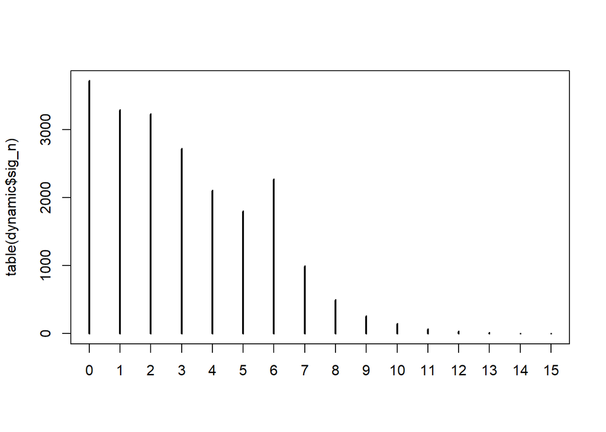

```r
plot(table(dynamic$sig_n))
```

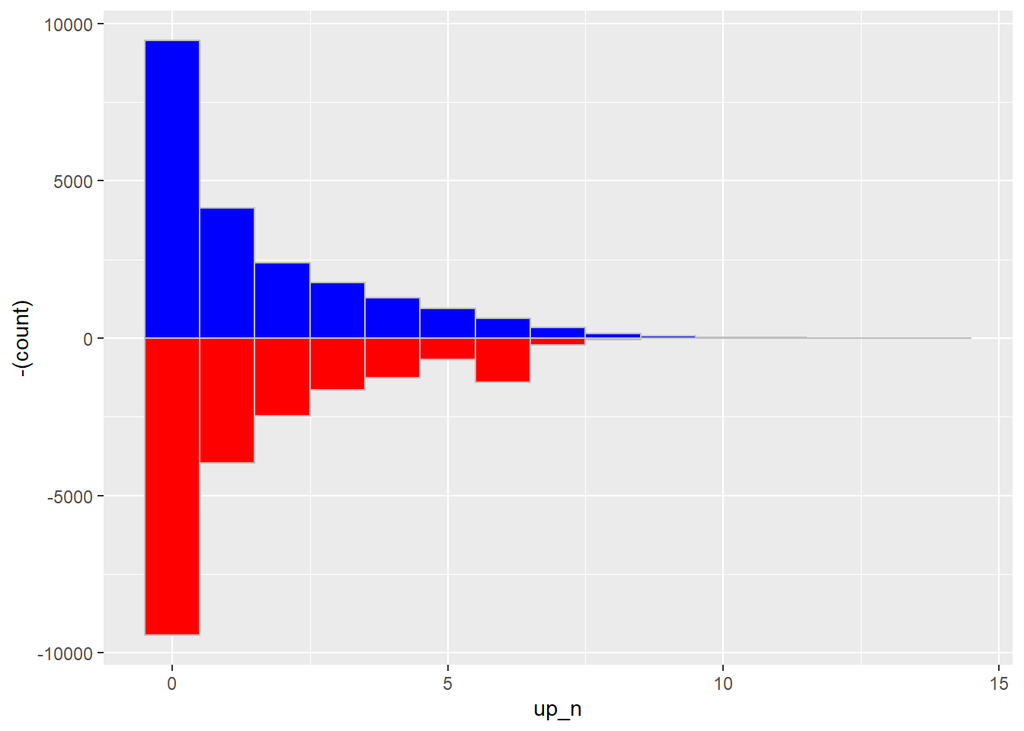

```r
ccount = function(x){return(-count(x))}

ggplot(dynamic) + geom_histogram(aes(x=up_n), fill="blue", binwidth = 1, colour="grey") +
  geom_histogram( aes(x=down_n, y=-(..count..)), fill="red", binwidth = 1, colour="grey")
```

```r
write.table(result, file.path(ous_dir,"Feb22_RNAseq/03limma/decideResults_pairwise_summary_plus0v15.tab" ), sep="\t")

binary = result
binary[binary == -1] = 1
write.table(binary, file.path(ous_dir,"Feb22_RNAseq/03limma/decideResults_pairwise_binary_plus0v15.txt" ), sep="\t")
```

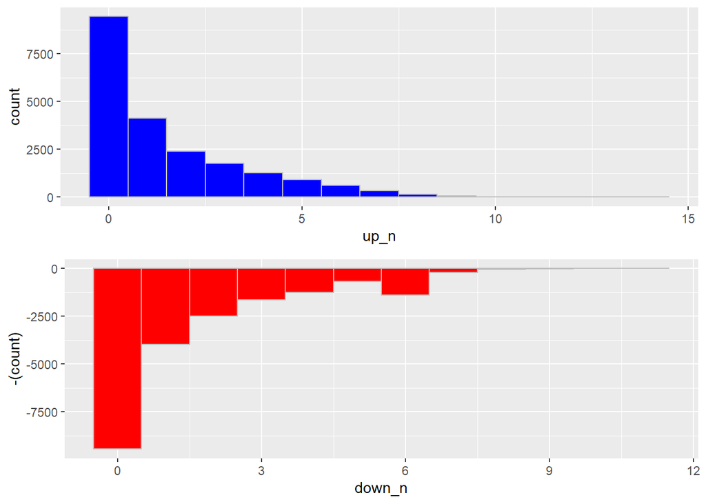

```r
top = ggplot(dynamic) + geom_histogram(aes(x=up_n), fill="blue", binwidth = 1, colour="grey")
b=  ggplot(dynamic) + geom_histogram( aes(x=down_n, y=-(..count..)), fill="red", binwidth = 1, colour="grey")

cowplot::plot_grid(top,b, ncol=1,nrow=2)
```

## Combine information into table

pairwise logFCs pairwise p-values for pro -> day0 -> day15 overview p-values for combined change across all diff (bulk only)

```r
head(pair_tab) #Remove pvalue cols from this table
```

```
##                          Geneid Length gene_name
## ENSG00000151726 ENSG00000151726   6284     ACSL1
## ENSG00000091513 ENSG00000091513  26199        TF
## ENSG00000099194 ENSG00000099194   5362       SCD
## ENSG00000056998 ENSG00000056998   3655      GYG2
## ENSG00000131471 ENSG00000131471   4524      AOC3
## ENSG00000076555 ENSG00000076555  14505     ACACB
##                                                     description d.2_to_d0.D7
## ENSG00000151726 acyl-CoA synthetase long chain family member 1    0.91308592
## ENSG00000091513                                    transferrin    2.91964435
## ENSG00000099194                        stearoyl-CoA desaturase    0.45467334
## ENSG00000056998                                   glycogenin 2   -0.01161201
## ENSG00000131471             amine oxidase, copper containing 3    2.70082420
## ENSG00000076555                    acetyl-CoA carboxylase beta    1.74317634
##                 d0_to_d1.D7 d1_to_d3.D7 d3_to_d9.D7 d9_to_d15.D7.bulk
## ENSG00000151726   2.7602331    1.725693   1.3160528        -0.3865382
## ENSG00000091513   1.1172857    2.921891   6.0369068         2.3572713
## ENSG00000099194   2.7099074    3.587873   1.9870490        -0.3653777
## ENSG00000056998   0.1777859    3.619636   2.6759316        -1.0258180
## ENSG00000131471   5.1992590    4.116078   1.0156618        -1.2375108
## ENSG00000076555   3.9075714    2.819020   0.7285706        -1.9493289
##                 d9_to_d15.D7.floating d15.bulk_to_floating.D7 d0_to_d15.D7
## ENSG00000151726            1.03482433                1.421363     5.415441
## ENSG00000091513            4.67653749                2.319266    12.433355
## ENSG00000099194            1.35084110                1.716219     7.919452
## ENSG00000056998            0.58264098                1.608459     5.447536
## ENSG00000131471            0.36948184                1.606993     9.093488
## ENSG00000076555           -0.02226711                1.927062     5.505833
##                 d.2_to_d0.D13 d0_to_d1.D13 d1_to_d3.D13 d3_to_d9.D13
## ENSG00000151726     0.6452748   3.05438100     2.299429    1.0913010
## ENSG00000091513     2.7614985   0.06419617     3.814639    4.2023963
## ENSG00000099194     0.5096742   3.12762271     3.663311    1.1408401
## ENSG00000056998    -0.3861738   1.07229675     3.137332    1.6003035
## ENSG00000131471     3.7248861   3.95139877     3.917213    0.4798536
## ENSG00000076555     1.1963788   4.61551565     2.686118    0.3403948
##                 d9_to_d15.D13.bulk d9_to_d15.D13.floating
## ENSG00000151726         -0.5024754              0.4653739
## ENSG00000091513          3.3895368              4.6857603
## ENSG00000099194         -0.3254461              0.5248709
## ENSG00000056998         -0.8310999             -0.3679659
## ENSG00000131471         -0.3926248             -0.3316135
## ENSG00000076555         -1.2162211             -0.4775969
##                 d15.bulk_to_floating.D13 d0_to_d15.D13   AveExpr        F
## ENSG00000151726               0.96784924      5.942635  8.810891 604.5501
## ENSG00000091513               1.29622350     11.470768  3.105257 456.3162
## ENSG00000099194               0.85031697      7.606328 11.807874 455.4452
## ENSG00000056998               0.46313398      4.978832  4.980263 383.7432
## ENSG00000131471               0.06101132      7.955841  6.379407 354.3822
## ENSG00000076555               0.73862419      6.425807  7.351638 343.7554
##                      P.Value    adj.P.Val
## ENSG00000151726 7.227877e-40 1.530431e-35
## ENSG00000091513 2.009818e-37 1.470916e-33
## ENSG00000099194 2.084040e-37 1.470916e-33
## ENSG00000056998 4.175967e-36 2.210548e-32
## ENSG00000131471 2.424643e-35 1.026788e-31
## ENSG00000076555 4.314697e-35 1.522657e-31
```

```r
pair_logFCs = pair_tab[-c((ncol(pair_tab)-3):ncol(pair_tab))]

pro_d0 = topTable(pair_fit, coef = c("d.2_to_d0.D7","d.2_to_d0.D13"), number = nrow(pair_fit$genes))
head(pro_d0)
```

```
##                          Geneid Length gene_name
## ENSG00000110031 ENSG00000110031   2467      LPXN
## ENSG00000164283 ENSG00000164283   2695      ESM1
## ENSG00000182326 ENSG00000182326   6462       C1S
## ENSG00000167191 ENSG00000167191   6667    GPRC5B
## ENSG00000111252 ENSG00000111252   5682     SH2B3
## ENSG00000228716 ENSG00000228716   4409      DHFR
##                                                          description
## ENSG00000110031                                            leupaxin
## ENSG00000164283                endothelial cell specific molecule 1
## ENSG00000182326                                      complement C1s
## ENSG00000167191 G protein-coupled receptor class C group 5 member B
## ENSG00000111252                              SH2B adaptor protein 3
## ENSG00000228716                             dihydrofolate reductase
##                 d.2_to_d0.D7 d.2_to_d0.D13   AveExpr        F      P.Value
## ENSG00000110031    -2.331966     -2.925604 3.3361035 270.0556 2.342580e-23
## ENSG00000164283    -6.158117     -5.517990 0.2466582 238.7425 2.381388e-22
## ENSG00000182326     4.084683      3.404293 9.2900714 191.9742 1.098302e-20
## ENSG00000167191     3.193671      3.221216 3.4604422 182.3227 2.588963e-20
## ENSG00000111252    -2.758401     -2.229507 5.5583472 177.8566 3.828181e-20
## ENSG00000228716    -2.654811     -2.035968 5.3448542 174.2049 5.356091e-20
##                    adj.P.Val
## ENSG00000110031 4.960179e-19
## ENSG00000164283 2.521176e-18
## ENSG00000182326 7.751815e-17
## ENSG00000167191 1.370467e-16
## ENSG00000111252 1.621158e-16
## ENSG00000228716 1.890164e-16
```

```r
d0_d15 = topTable(pair_fit, coef = c("d0_to_d15.D7","d0_to_d15.D13"), number = nrow(pair_fit$genes))
head(d0_d15)
```

```
##                          Geneid Length gene_name
## ENSG00000151726 ENSG00000151726   6284     ACSL1
## ENSG00000099194 ENSG00000099194   5362       SCD
## ENSG00000042445 ENSG00000042445   4005    RETSAT
## ENSG00000091513 ENSG00000091513  26199        TF
## ENSG00000056998 ENSG00000056998   3655      GYG2
## ENSG00000131471 ENSG00000131471   4524      AOC3
##                                                     description d0_to_d15.D7
## ENSG00000151726 acyl-CoA synthetase long chain family member 1      5.415441
## ENSG00000099194                        stearoyl-CoA desaturase      7.919452
## ENSG00000042445                               retinol saturase      3.774130
## ENSG00000091513                                    transferrin     12.433355
## ENSG00000056998                                   glycogenin 2      5.447536
## ENSG00000131471             amine oxidase, copper containing 3      9.093488
##                 d0_to_d15.D13   AveExpr        F      P.Value    adj.P.Val
## ENSG00000151726      5.942635  8.810891 870.4305 9.852473e-33 2.086163e-28
## ENSG00000099194      7.606328 11.807874 734.9480 2.848250e-31 3.015442e-27
## ENSG00000042445      4.534216  7.100134 566.5239 3.031496e-29 2.139630e-25
## ENSG00000091513     11.470768  3.105257 545.3532 7.286426e-29 3.857070e-25
## ENSG00000056998      4.978832  4.980263 512.5804 1.940830e-28 8.219026e-25
## ENSG00000131471      7.955841  6.379407 407.2577 1.568185e-26 5.534124e-23
```

```r
head(comb)
```

```
##                          Geneid Length gene_name
## ENSG00000151726 ENSG00000151726   6284     ACSL1
## ENSG00000099194 ENSG00000099194   5362       SCD
## ENSG00000091513 ENSG00000091513  26199        TF
## ENSG00000056998 ENSG00000056998   3655      GYG2
## ENSG00000042445 ENSG00000042445   4005    RETSAT
## ENSG00000131471 ENSG00000131471   4524      AOC3
##                                                     description
## ENSG00000151726 acyl-CoA synthetase long chain family member 1
## ENSG00000099194                        stearoyl-CoA desaturase
## ENSG00000091513                                    transferrin
## ENSG00000056998                                   glycogenin 2
## ENSG00000042445                               retinol saturase
## ENSG00000131471             amine oxidase, copper containing 3
##                 time_effect_donor7 time_effect_donor13   AveExpr         F
## ENSG00000151726           6.328527            6.587910  8.810891 1311.9218
## ENSG00000099194           8.374125            8.116002 11.807874  977.5321
## ENSG00000091513          15.353000           14.232266  3.105257  772.2557
## ENSG00000056998           5.435924            4.592658  4.980263  682.1157
## ENSG00000042445           3.744336            4.451633  7.100134  664.3419
## ENSG00000131471          11.794312           11.680727  6.379407  583.7419
##                      P.Value    adj.P.Val
## ENSG00000151726 4.270495e-36 9.042346e-32
## ENSG00000099194 1.365663e-33 1.445828e-29
## ENSG00000091513 1.129907e-31 7.974881e-28
## ENSG00000056998 9.517809e-31 5.038252e-27
## ENSG00000042445 1.558726e-30 6.600891e-27
## ENSG00000131471 2.067426e-29 6.789009e-26
```

```r
final = merge(comb, d0_d15[c("Geneid","d0_to_d15.D7","d0_to_d15.D13","P.Value","adj.P.Val")],
              suffixes=c("",".d0_to_d15"), by="Geneid")
final = merge(final, pro_d0[c("Geneid","d.2_to_d0.D7","d.2_to_d0.D13","P.Value","adj.P.Val")],
              suffixes=c(".overall",".d.2_to_d0"), by="Geneid")
head(final)
```

```
##            Geneid Length gene_name
## 1 ENSG00000000003   4535    TSPAN6
## 2 ENSG00000000005   1610      TNMD
## 3 ENSG00000000419   1207      DPM1
## 4 ENSG00000000457   6883     SCYL3
## 5 ENSG00000000460   5967  C1orf112
## 6 ENSG00000000938   3474       FGR
##                                                    description
## 1                                               tetraspanin 6
## 2                                                 tenomodulin
## 3 dolichyl-phosphate mannosyltransferase subunit 1, catalytic
## 4                                    SCY1 like pseudokinase 3
## 5                         chromosome 1 open reading frame 112
## 6              FGR proto-oncogene, Src family tyrosine kinase
##   time_effect_donor7 time_effect_donor13   AveExpr          F P.Value.overall
```

[output cut: 27 more lines]

```r
write.table(final, file.path(ous_dir,"Feb22_RNAseq/03limma/pro_d0_d15_results.tab" ), sep="\t", row.names = F)
```

## GO Day0 -> day15

```r
molsig <- read.gmt("C:/Users/sarahhp/OneDrive - Universitetet i Oslo/OUS/D13rnaseqDec19/R/msigdb.v7.4.symbols.gmt")
head(molsig); nrow(molsig)
```

```
##      term      gene
## 1 chr1p12     VTCN1
## 2 chr1p12 LINC01525
## 3 chr1p12    MAN1A2
## 4 chr1p12   VPS25P1
## 5 chr1p12    TENT5C
## 6 chr1p12   VDAC2P3
```

```
## [1] 3854442
```

```r
##Pick gene sets to look in bcos all is a lot
prefixes = c("HALLMARK", "KEGG","REACTOME", "WP", "GOBP", "GOCC","GOMF")
some.molsig = molsig[gsub("_.*","", molsig$term) %in% prefixes,]
some.molsig$term = factor(some.molsig$term)
table(gsub("_.*","", some.molsig$term))
```

```
##
##     GOBP     GOCC     GOMF HALLMARK     KEGG REACTOME       WP
##   636699    97202   103847     7321    12797    89457    27711
```

```r
length(final$gene_name[final$P.Value.d0_to_d15 < 0.01 &
                                            final$d0_to_d15.D7 < 0 &
                                            final$d0_to_d15.D13 < 0])
```

```
## [1] 5491
```

```r
go_down = enricher(gene=final$gene_name[final$P.Value.d0_to_d15 < 0.01 &
                                            final$d0_to_d15.D7 < 0 &
                                            final$d0_to_d15.D13 < 0],
              TERM2GENE = some.molsig,
              minGSSize = 10,
              universe = final$gene_name)
head(go_down, n=20)[c(3:7)]
```

```
##                                                                GeneRatio
## GOBP_CILIUM_ORGANIZATION                                        122/2887
## GOBP_SKELETAL_SYSTEM_DEVELOPMENT                                135/2887
## WP_CILIOPATHIES                                                  66/2887
## GOBP_BONE_DEVELOPMENT                                            64/2887
## WP_GENES_RELATED_TO_PRIMARY_CILIUM_DEVELOPMENT_BASED_ON_CRISPR   44/2887
## GOCC_POSTSYNAPTIC_MEMBRANE                                       66/2887
## HALLMARK_UV_RESPONSE_DN                                          57/2887
## WP_PATHWAYS_AFFECTED_IN_ADENOID_CYSTIC_CARCINOMA                 31/2887
## GOCC_CILIUM                                                     146/2887
## GOBP_CARTILAGE_DEVELOPMENT                                       58/2887
## GOMF_PROTEIN_SERINE_THREONINE_KINASE_ACTIVITY                   122/2887
## GOCC_CILIARY_BASAL_BODY                                          53/2887
## GOCC_CENTRIOLE                                                   50/2887
## WP_ENDODERM_DIFFERENTIATION                                      47/2887
## GOCC_SYNAPTIC_MEMBRANE                                           87/2887
## GOBP_POSITIVE_REGULATION_OF_CHROMATIN_ORGANIZATION               39/2887
## GOMF_HISTONE_BINDING                                             75/2887
## GOBP_EMBRYONIC_MORPHOGENESIS                                    137/2887
## GOBP_REGULATION_OF_CHROMATIN_ORGANIZATION                        58/2887
## GOBP_CHONDROCYTE_DIFFERENTIATION                                 38/2887
##                                                                  BgRatio
## GOBP_CILIUM_ORGANIZATION                                       336/13605
## GOBP_SKELETAL_SYSTEM_DEVELOPMENT                               392/13605
## WP_CILIOPATHIES                                                158/13605
## GOBP_BONE_DEVELOPMENT                                          157/13605
## WP_GENES_RELATED_TO_PRIMARY_CILIUM_DEVELOPMENT_BASED_ON_CRISPR  96/13605
## GOCC_POSTSYNAPTIC_MEMBRANE                                     173/13605
## HALLMARK_UV_RESPONSE_DN                                        143/13605
## WP_PATHWAYS_AFFECTED_IN_ADENOID_CYSTIC_CARCINOMA                61/13605
## GOCC_CILIUM                                                    474/13605
## GOBP_CARTILAGE_DEVELOPMENT                                     149/13605
## GOMF_PROTEIN_SERINE_THREONINE_KINASE_ACTIVITY                  385/13605
## GOCC_CILIARY_BASAL_BODY                                        134/13605
## GOCC_CENTRIOLE                                                 125/13605
## WP_ENDODERM_DIFFERENTIATION                                    115/13605
## GOCC_SYNAPTIC_MEMBRANE                                         258/13605
## GOBP_POSITIVE_REGULATION_OF_CHROMATIN_ORGANIZATION              90/13605
## GOMF_HISTONE_BINDING                                           215/13605
## GOBP_EMBRYONIC_MORPHOGENESIS                                   452/13605
```

[output cut: 50 more lines]

```
## GOCC_POSTSYNAPTIC_MEMBRANE                                     2.714288e-04
## HALLMARK_UV_RESPONSE_DN                                        2.714288e-04
## WP_PATHWAYS_AFFECTED_IN_ADENOID_CYSTIC_CARCINOMA               2.714288e-04
## GOCC_CILIUM                                                    3.376566e-04
## GOBP_CARTILAGE_DEVELOPMENT                                     4.166309e-04
## GOMF_PROTEIN_SERINE_THREONINE_KINASE_ACTIVITY                  4.950770e-04
## GOCC_CILIARY_BASAL_BODY                                        5.889193e-04
## GOCC_CENTRIOLE                                                 6.858459e-04
## WP_ENDODERM_DIFFERENTIATION                                    6.858459e-04
## GOCC_SYNAPTIC_MEMBRANE                                         8.387700e-04
## GOBP_POSITIVE_REGULATION_OF_CHROMATIN_ORGANIZATION             8.387700e-04
## GOMF_HISTONE_BINDING                                           9.497945e-04
## GOBP_EMBRYONIC_MORPHOGENESIS                                   9.831393e-04
## GOBP_REGULATION_OF_CHROMATIN_ORGANIZATION                      9.831393e-04
## GOBP_CHONDROCYTE_DIFFERENTIATION                               1.004183e-03
```

```r
paste("And", max(0,nrow(go_down)-20), "other terms above pval threshold")
```

```
## [1] "And 143 other terms above pval threshold"
```

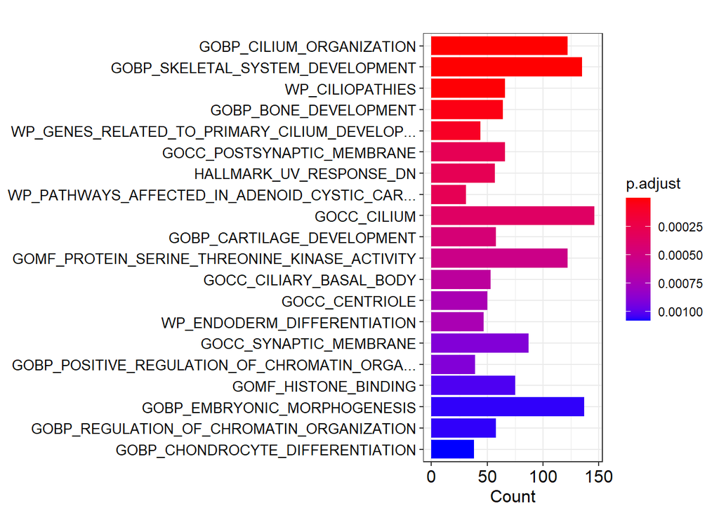

```r
barplot(go_down, showCategory=20) + scale_y_discrete(label=function(x) stringr::str_trunc(x,45)) +
    theme(axis.text.y = element_text(size=10))
```

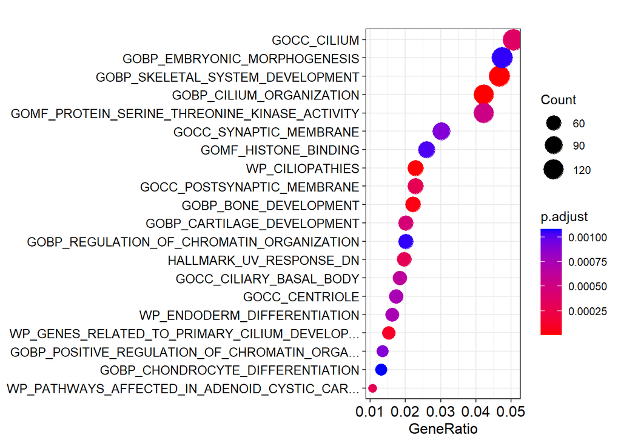

```r
dotplot(go_down, showCategory=20) + scale_y_discrete(label=function(x) stringr::str_trunc(x,45)) +
    theme(axis.text.y = element_text(size=10))
```

Theres some weird stuff in here, cilium, skeletal system development, but also histone binding and regulation of chromatin organisation. I suppose the skeletal stuff makes sense.

```r
length(final$gene_name[final$P.Value.d0_to_d15 < 0.01 &
                                            final$d0_to_d15.D7 > 0 &
                                            final$d0_to_d15.D13 > 0])
```

```
## [1] 5116
```

```r
go_up = enricher(gene=final$gene_name[final$P.Value.d0_to_d15 < 0.01 &
                                            final$d0_to_d15.D7 > 0 &
                                            final$d0_to_d15.D13 > 0],
              TERM2GENE = some.molsig,
              minGSSize = 10,
              universe = final$gene_name)
head(go_up, n=20)[c(3:8)]
```

```
##                                                                                                                           GeneRatio
## HALLMARK_OXIDATIVE_PHOSPHORYLATION                                                                                         164/3902
## GOCC_MITOCHONDRIAL_MATRIX                                                                                                  280/3902
## HALLMARK_ADIPOGENESIS                                                                                                      148/3902
## GOBP_GENERATION_OF_PRECURSOR_METABOLITES_AND_ENERGY                                                                        262/3902
## REACTOME_THE_CITRIC_ACID_TCA_CYCLE_AND_RESPIRATORY_ELECTRON_TRANSPORT                                                      130/3902
## GOCC_MITOCHONDRIAL_PROTEIN_CONTAINING_COMPLEX                                                                              170/3902
## REACTOME_METABOLISM_OF_AMINO_ACIDS_AND_DERIVATIVES                                                                         194/3902
## REACTOME_TRANSLATION                                                                                                       165/3902
## GOBP_ENERGY_DERIVATION_BY_OXIDATION_OF_ORGANIC_COMPOUNDS                                                                   155/3902
## GOBP_OXIDATIVE_PHOSPHORYLATION                                                                                             100/3902
## GOBP_CELLULAR_RESPIRATION                                                                                                  117/3902
## REACTOME_RESPIRATORY_ELECTRON_TRANSPORT_ATP_SYNTHESIS_BY_CHEMIOSMOTIC_COUPLING_AND_HEAT_PRODUCTION_BY_UNCOUPLING_PROTEINS   93/3902
## HALLMARK_FATTY_ACID_METABOLISM                                                                                             100/3902
## GOBP_ELECTRON_TRANSPORT_CHAIN                                                                                              109/3902
## GOBP_FATTY_ACID_METABOLIC_PROCESS                                                                                          173/3902
## GOCC_RIBOSOMAL_SUBUNIT                                                                                                     116/3902
## WP_ELECTRON_TRANSPORT_CHAIN_OXPHOS_SYSTEM_IN_MITOCHONDRIA                                                                   77/3902
## GOCC_INNER_MITOCHONDRIAL_MEMBRANE_PROTEIN_COMPLEX                                                                           94/3902
## GOBP_ORGANIC_ACID_CATABOLIC_PROCESS                                                                                        129/3902
## REACTOME_RESPIRATORY_ELECTRON_TRANSPORT                                                                                     76/3902
##                                                                                                                             BgRatio
## HALLMARK_OXIDATIVE_PHOSPHORYLATION                                                                                        200/13605
## GOCC_MITOCHONDRIAL_MATRIX                                                                                                 449/13605
## HALLMARK_ADIPOGENESIS                                                                                                     195/13605
## GOBP_GENERATION_OF_PRECURSOR_METABOLITES_AND_ENERGY                                                                       463/13605
## REACTOME_THE_CITRIC_ACID_TCA_CYCLE_AND_RESPIRATORY_ELECTRON_TRANSPORT                                                     174/13605
## GOCC_MITOCHONDRIAL_PROTEIN_CONTAINING_COMPLEX                                                                             256/13605
## REACTOME_METABOLISM_OF_AMINO_ACIDS_AND_DERIVATIVES                                                                        312/13605
## REACTOME_TRANSLATION                                                                                                      271/13605
## GOBP_ENERGY_DERIVATION_BY_OXIDATION_OF_ORGANIC_COMPOUNDS                                                                  250/13605
## GOBP_OXIDATIVE_PHOSPHORYLATION                                                                                            135/13605
## GOBP_CELLULAR_RESPIRATION                                                                                                 173/13605
## REACTOME_RESPIRATORY_ELECTRON_TRANSPORT_ATP_SYNTHESIS_BY_CHEMIOSMOTIC_COUPLING_AND_HEAT_PRODUCTION_BY_UNCOUPLING_PROTEINS 127/13605
## HALLMARK_FATTY_ACID_METABOLISM                                                                                            144/13605
## GOBP_ELECTRON_TRANSPORT_CHAIN                                                                                             163/13605
## GOBP_FATTY_ACID_METABOLIC_PROCESS                                                                                         310/13605
## GOCC_RIBOSOMAL_SUBUNIT                                                                                                    181/13605
## WP_ELECTRON_TRANSPORT_CHAIN_OXPHOS_SYSTEM_IN_MITOCHONDRIA                                                                 102/13605
## GOCC_INNER_MITOCHONDRIAL_MEMBRANE_PROTEIN_COMPLEX                                                                         137/13605
```

[output cut: 71 more lines]

[output not shown]